# Final Project Biol 4080

Sammy Durbin

2026-05-12

```r
library(readr)
```

```r
library(ggplot2)
library(dplyr)
library(bio3d)
library(stringr)
library(igraph)
library(rgl)
```

# Introduction

In the early 1900s, Hans Gerhard Creutzfeldt and Alfons Maria Jakob noted patients with a rapidly progressive and fatal neurological disease distinguished by dementia, motor dysfunction such as stiffness and involuntary jerking movements, loss of balance, and, on autopsy, spongy degeneration in the brain tissue.<sup>1,2</sup> In his 1922 work, Walther Spielmeyer grouped the cases described by Creutzfeldt and Jakob as a single, distinct neurodegenerative disease entity<sup>3</sup> introducing the designation later known as Creutzfeldt–Jakob disease (CJD).

The causative agent behind CJD was revealed as a proteinaceous infectious particle (prion) by Stanley Prusiner<sup>4</sup> in 1982, with key details on the neurotoxic aggregates provided by Byron Caughey and Peter Lansbury’s research, and mechanistic insights through Mari DeMarco and Valerie Dagget’s work, explaining how prions form toxic accumulations given enough time.<sup>5,6</sup> Misfolded PRNP induces conformational changes in other PRNP neighbors, forming toxic oligomers that accumulate eventually forming large enough clumps to impede brain and nervous system function. This process is irreversible and always leads to death in those diagnosed with the disease.<sup>7</sup>

PRNP is interesting as while there are several mutations that occur genetically, there is also a spontaneous arise of a fatal disease documented in patient populations.<sup>8</sup> This paper aims to investigate the structural features of pathogenic genetic PRNP variants using biostatistical analysis of clinical and structural data to identify key regions of instability that, when mutated, lead to protein misfolding and disease.

# Methods

The crystal structure 1QLX of PRNP serves as a structural reference of the wild type PRNP.<sup>9</sup> Cα coordinates were extracted and used to compute a pairwise distance matrix. A residue interaction network was constructed by defining edges between residues whose Cα atoms were within 8 Å - a commonly used threshold in protein contact and residue interaction network analyses^15. From this network, structural features were computed such as number of contacts per residue (degree) and betweenness centrality (how frequently a residue lies on the shortest paths between other residues)<sup>11,15</sup>

For assessment of diseased PRNP, the ClinVar dataset was utilized. Containing 230 genetic mutations of PRNP, the dataset contained pathogenicity of the mutation, germline classification, variant type, and residue number.<sup>10</sup> ClinVar variants were mapped onto the 1QLX structure by residue number, allowing integration of structural features with mutation data. Residues were categorized into five structural regions (Helix 1, Helix 2, Helix 3, β2–α2 loop, or other).<sup>12</sup>

Logistic regression models were constructed to evaluate the association between structural features and mutation pathogenicity. Multiple models were tested, including combinations of degree, betweenness centrality, and structural region, and compared using Akaike Information Criterion (AIC) to identify the model of best fit. Additionally, a Wilcoxon rank-sum test<sup>13</sup> was used to compare residue contact degree between pathogenic and non-pathogenic variants, to assess if there is an association between degree and pathogenicity.

# Code

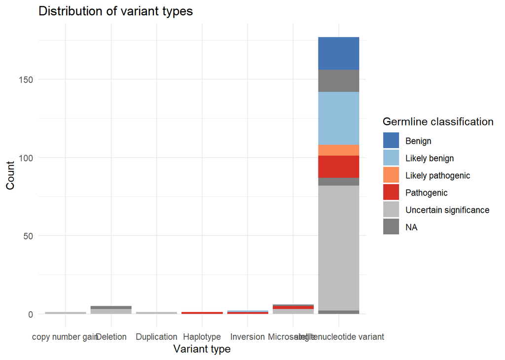

```r
# -----------------------------
# Load Libraries
# -----------------------------

library(readr)
library(ggplot2)
library(dplyr)
library(bio3d)
library(stringr)
library(igraph)
library(rgl)

# -----------------------------
# Load Data
# -----------------------------

prnp_data <- read_tsv(
  "clinvar_result.txt",
  col_types = cols(.default = "c"),
  na = c("", "NA")
)
# ------------------------------
# isolate key columns
# ------------------------------

df_focus <- prnp_data %>%
  filter(`Gene(s)` == "PRNP") %>%
  select(
    `Protein change`,
    `Molecular consequence`,
    `Variant type`,
    `Germline classification`
  )

# ------------------------------
# identify variant types and classifications
# ------------------------------

df_focus %>%
  count(`Variant type`, `Germline classification`) %>%
  ggplot(aes(x = `Variant type`, y = n, fill = `Germline classification`)) +
  geom_col() +
  theme_minimal() +
  scale_fill_manual(values = c(
    "Pathogenic" = "#d73027",
    "Likely pathogenic" = "#fc8d59",
    "Uncertain significance" = "#bdbdbd",
    "Likely benign" = "#91bfdb",
    "Benign" = "#4575b4"
  )) +
  labs(
    x = "Variant type",
    y = "Count",
    fill = "Germline classification",
    title = "Distribution of variant types"
  )
```

```r
# ------------------------------
# Residue level plot
# ------------------------------

df_path <- prnp_data %>%
  filter(`Gene(s)` == "PRNP") %>%
  filter(!is.na(`Protein change`), `Protein change` != "") %>%
  filter(grepl("^[A-Z][0-9]+[A-Z]$", `Protein change`)) %>%
  filter(grepl("missense|nonsense", `Molecular consequence`, ignore.case = TRUE)) %>%
  filter(grepl("Pathogenic", `Germline classification`, ignore.case = TRUE))

df_parsed <- df_path %>%
  mutate(
    wt_aa  = str_extract(`Protein change`, "^[A-Z]"),
    mut_aa = str_extract(`Protein change`, "[A-Z]$"),
    residue = as.integer(str_extract(`Protein change`, "[0-9]+"))
  )

df_counts <- df_parsed %>%
  count(`Protein change`, wt_aa, mut_aa, residue, sort = TRUE)

print(df_counts, n = 50)
```

```
## # A tibble: 24 × 5
##    `Protein change` wt_aa mut_aa residue     n
##    <chr>            <chr> <chr>    <int> <int>
##  1 A117V            A     V          117     2
##  2 A118V            A     V          118     1
##  3 A133V            A     V          133     1
##  4 A2V              A     V            2     1
##  5 D178N            D     N          178     1
##  6 E200K            E     K          200     1
##  7 E211Q            E     Q          211     1
##  8 F198S            F     S          198     1
##  9 G131E            G     E          131     1
## 10 G131V            G     V          131     1
## 11 H187R            H     R          187     1
## 12 P102L            P     L          102     1
## 13 P105L            P     L          105     1
## 14 P105T            P     T          105     1
## 15 P39L             P     L           39     1
## 16 Q212P            Q     P          212     1
## 17 Q217R            Q     R          217     1
## 18 R148H            R     H          148     1
## 19 R208H            R     H          208     1
## 20 R48H             R     H           48     1
## 21 T183A            T     A          183     1
## 22 T188R            T     R          188     1
## 23 V180I            V     I          180     1
## 24 V210I            V     I          210     1
```

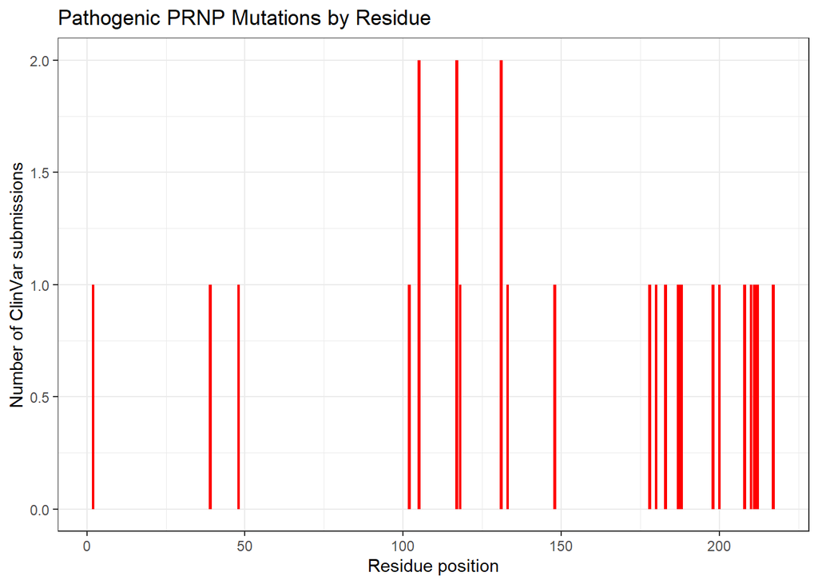

```r
ggplot(df_counts, aes(x = residue, y = n)) +
  geom_col(fill = "red") +
  theme_bw() +
  labs(
    title = "Pathogenic PRNP Mutations by Residue",
    x = "Residue position",
    y = "Number of ClinVar submissions"
  )
```

```r
# ------------------------------
# Load 1QLX structure and build contact network
# ------------------------------

pdb <- read.cif("1qlx.cif")
```

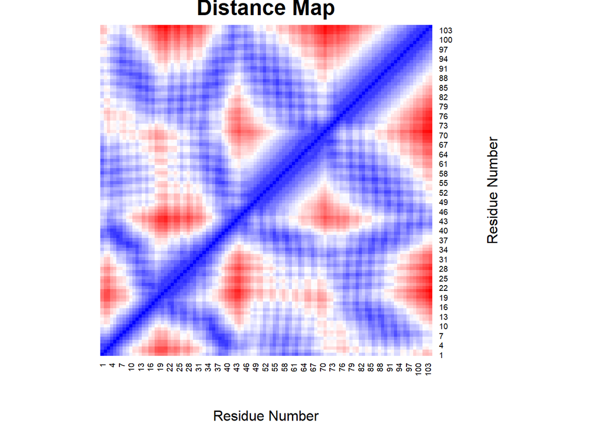

```r
ca <- atom.select(pdb, elety = "CA")

coords <- pdb$xyz[ca$xyz]
coords_matrix <- matrix(coords, ncol = 3, byrow = TRUE)

resno <- pdb$atom$resno[ca$atom]
resid <- pdb$atom$resid[ca$atom]

dist_matrix <- as.matrix(dist(coords_matrix))

threshold <- 8
contacts <- dist_matrix < threshold
diag(contacts) <- FALSE

g <- graph_from_adjacency_matrix(
  contacts,
  mode = "undirected",
  diag = FALSE
)

# Compute structural network features
btw <- betweenness(g, normalized = TRUE)
deg <- degree(g)

# ------------------------------
# Distance map
# ------------------------------

heatmap(
  dist_matrix,
  Rowv = NA,
  Colv = NA,
  col = colorRampPalette(c("blue", "white", "red"))(100),
  scale = "none",
  xlab = "Residue Number",
  ylab = "Residue Number",
  main = "Distance Map"
)
```

```r
# ------------------------------
# Centrality stuff
# ------------------------------

centrality_df <- data.frame(
  index = seq_along(btw),
  resno = resno,
  resid = resid,
  betweenness = btw
)

centrality_df <- centrality_df[order(-centrality_df$betweenness), ]

head(centrality_df, 20)
```

```
##    index resno resid betweenness
## 60    60   184   ILE  0.10905888
## 85    85   209   VAL  0.10464799
## 89    89   213   MET  0.10162908
## 86    86   210   VAL  0.09934070
## 37    37   161   VAL  0.09210395
## 55    55   179   CYS  0.07757674
## 81    81   205   MET  0.07619471
## 59    59   183   THR  0.07361324
## 15    15   139   ILE  0.06795466
## 87    87   211   GLU  0.06758306
## 82    82   206   MET  0.06338505
## 93    93   217   GLN  0.06246165
## 38    38   162   TYR  0.06097444
## 26    26   150   TYR  0.05983159
## 83    83   207   GLU  0.05772870
## 58    58   182   ILE  0.05739231
## 52    52   176   VAL  0.05702851
## 12    12   136   ARG  0.05312948
## 79    79   203   VAL  0.05308421
## 14    14   138   ILE  0.05278939
```

```r
# Top 10% most central residues
cutoff <- quantile(btw, 0.90)

high_cent <- btw >= cutoff

high_cent_residues <- data.frame(
  index = which(high_cent),
  resno = resno[high_cent],
  resid = resid[high_cent],
  betweenness = btw[high_cent]
)

high_cent_residues
```

```
##    index resno resid betweenness
## 15    15   139   ILE  0.06795466
## 37    37   161   VAL  0.09210395
## 55    55   179   CYS  0.07757674
## 59    59   183   THR  0.07361324
## 60    60   184   ILE  0.10905888
## 81    81   205   MET  0.07619471
## 82    82   206   MET  0.06338505
## 85    85   209   VAL  0.10464799
## 86    86   210   VAL  0.09934070
## 87    87   211   GLU  0.06758306
## 89    89   213   MET  0.10162908
```

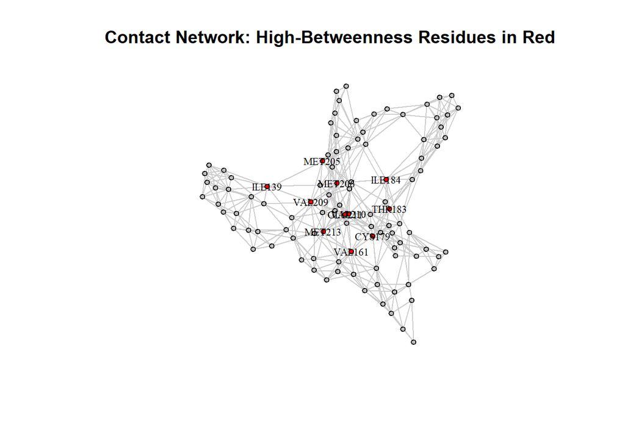

```r
V(g)$size <- 4
V(g)$color <- ifelse(high_cent, "red", "gray")

# Label only high-betweenness residues
vertex_labels <- ifelse(
  high_cent,
  paste0(resid, resno),
  NA
)

plot(
  g,
  vertex.label = vertex_labels,
  vertex.label.cex = 0.7,
  vertex.label.color = "black",
  vertex.size = V(g)$size,
  vertex.color = V(g)$color,
  edge.color = "gray80",
  main = "Contact Network: High-Betweenness Residues in Red"
)
```

```r
# ------------------------------
# 3D centrality visualization
# ------------------------------

open3d()
```

```
## wgl
##   1
```

```r
# Plot all C-alpha atoms
spheres3d(
  coords_matrix,
  radius = 0.6,
  color = "gray"
)

# Plot high-centrality C-alpha atoms
spheres3d(
  coords_matrix[high_cent, ],
  radius = 1.2,
  color = "red"
)

# Draw backbone trace
lines3d(coords_matrix, color = "black", lwd = 2)

# Add residue labels for high-centrality residues
text3d(
  coords_matrix[high_cent, ],
  texts = paste0(resid[high_cent], resno[high_cent]),
  color = "red",
  cex = 0.8
)

# ------------------------------
# Permutation test for clustering near functional sites
# ------------------------------

# pick functional residues
functional_resno <- c(
  165:175,                  # β2–α2 loop
  178, 200, 208, 210, 217,  # disease mutations
  179, 214                  # disulfide bond
)

functional_idx <- which(resno %in% functional_resno)
high_idx <- which(high_cent)

# Minimum distance from each high-centrality residue to functional site
obs_dist <- apply(dist_matrix[high_idx, functional_idx, drop = FALSE], 1, min)
obs_mean <- mean(obs_dist)

# Permutation test
# “What would this distance look like if I picked random residues instead of high-centrality ones?”

set.seed(123)

n_perm <- 10000
perm_means <- numeric(n_perm)

for (i in 1:n_perm) {
  # picking random set of residues that is the same size as the high centrality set
  random_idx <- sample(seq_along(resno), length(high_idx))

  # for each random residue, find the closest functional residue
  random_dist <- apply(dist_matrix[random_idx, functional_idx, drop = FALSE], 1, min)

  # compute average distance for this random set
  perm_means[i] <- mean(random_dist)
}

p_value <- mean(perm_means <= obs_mean)

obs_mean
```

```
## [1] 4.491983
```

```r
p_value
```

```
## [1] 0.0122
```

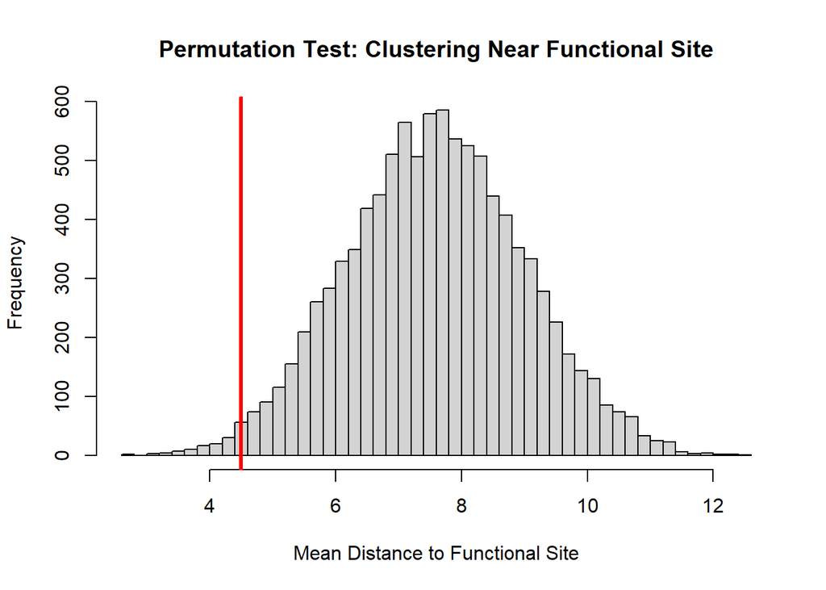

```r
hist(
  perm_means,
  breaks = 50,
  main = "Permutation Test: Clustering Near Functional Site",
  xlab = "Mean Distance to Functional Site"
)

abline(v = obs_mean, col = "red", lwd = 3)
```

```r
if (p_value < 0.05) {
  print("High-centrality residues are significantly clustered near the functional site.")
} else {
  print("No significant clustering near the functional site detected.")
}
```

```
## [1] "High-centrality residues are significantly clustered near the functional site."
```

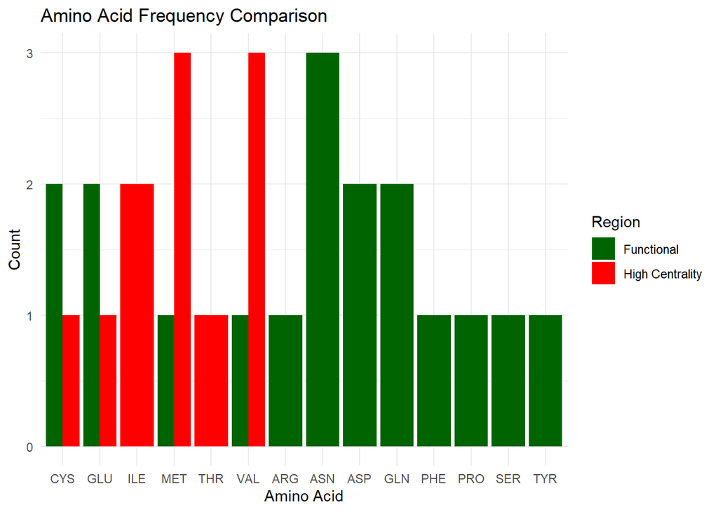

```r
# ------------------------------
# Amino acid frequency comparison
# ------------------------------

# Extract amino acids
aa_high <- resid[high_cent]
aa_func <- resid[functional_idx]

# Frequency tables
freq_high <- table(aa_high)
freq_func <- table(aa_func)

# Convert to data frames
df_high <- as.data.frame(freq_high)
colnames(df_high) <- c("AminoAcid", "Count")
df_high$Region <- "High Centrality"

df_func <- as.data.frame(freq_func)
colnames(df_func) <- c("AminoAcid", "Count")
df_func$Region <- "Functional"

# Combine
df_all <- rbind(df_high, df_func)

# Plot counts
ggplot(df_all, aes(x = AminoAcid, y = Count, fill = Region)) +
  geom_bar(stat = "identity", position = "dodge") +
  scale_fill_manual(values = c(
    "High Centrality" = "red",
    "Functional" = "darkgreen"
  )) +
  theme_minimal() +
  labs(
    title = "Amino Acid Frequency Comparison",
    x = "Amino Acid",
    y = "Count"
  )
```

```r
# ------------------------------
# Make structural table from 1QLX C-alpha atoms
# ------------------------------

pdb_map <- data.frame(
  residue = resno,
  pdb_residue_name = resid,
  betweenness = btw,
  degree = deg
) %>%
  mutate(region = case_when(
    residue >= 144 & residue <= 154 ~ "Helix 1",
    residue >= 165 & residue <= 172 ~ "β2–α2 loop",
    residue >= 173 & residue <= 194 ~ "Helix 2",
    residue >= 200 & residue <= 228 ~ "Helix 3",
    TRUE ~ "Other"
  ))

# ------------------------------
# Mapped table for pathogenic ClinVar PRNP protein changes
# ------------------------------

clinvar_pathogenic_map <- df_counts %>%
  mutate(pathogenic = 1)

mapped_mutations <- clinvar_pathogenic_map %>%
  mutate(residue = as.numeric(residue)) %>%
  filter(residue >= 125 & residue <= 228) %>%
  left_join(pdb_map, by = "residue") %>%
  arrange(residue) %>%
  select(
    `Protein change`,
    residue,
    betweenness,
    degree,
    region
  )

print(mapped_mutations, n = Inf)
```

```
## # A tibble: 16 × 5
##    `Protein change` residue betweenness degree region
##    <chr>              <dbl>       <dbl>  <dbl> <chr>
##  1 G131E                131     0.0186       9 Other
##  2 G131V                131     0.0186       9 Other
##  3 A133V                133     0.00421      7 Other
##  4 R148H                148     0.00400      8 Helix 1
##  5 D178N                178     0.0137       8 Helix 2
##  6 V180I                180     0.0502      13 Helix 2
##  7 T183A                183     0.0736      11 Helix 2
##  8 H187R                187     0.0397       9 Helix 2
##  9 T188R                188     0.0423      11 Helix 2
## 10 F198S                198     0.0300       8 Other
## 11 E200K                200     0.00115      6 Helix 3
## 12 R208H                208     0.0441       9 Helix 3
## 13 V210I                210     0.0993      15 Helix 3
## 14 E211Q                211     0.0676      12 Helix 3
## 15 Q212P                212     0.0236       9 Helix 3
## 16 Q217R                217     0.0625      10 Helix 3
```

```r
# ------------------------------
# Mapped table for ALL ClinVar PRNP protein changes
# pathogenic + non-pathogenic
# ------------------------------

clinvar_all_map <- prnp_data %>%
  filter(`Gene(s)` == "PRNP") %>%
  filter(!is.na(`Protein change`), `Protein change` != "") %>%
  filter(grepl("^[A-Z][0-9]+[A-Z]$", `Protein change`)) %>%
  filter(grepl("missense|nonsense", `Molecular consequence`, ignore.case = TRUE)) %>%
  mutate(
    residue = as.numeric(str_extract(`Protein change`, "[0-9]+")),
    pathogenic = ifelse(
      grepl("Pathogenic", `Germline classification`, ignore.case = TRUE),
      1, 0
    )
  ) %>%
  filter(residue >= 125 & residue <= 228)

mapped_all_mutations <- clinvar_all_map %>%
  left_join(pdb_map, by = "residue") %>%
  arrange(residue) %>%
  select(
    `Protein change`,
    residue,
    `Germline classification`,
    pathogenic,
    betweenness,
    degree,
    region
  )

print(mapped_all_mutations, n = Inf)
```

```
## # A tibble: 50 × 7
##    `Protein change` residue Germline classificat…¹ pathogenic betweenness degree
##    <chr>              <dbl> <chr>                       <dbl>       <dbl>  <dbl>
##  1 G127V                127 protective                      0   0.00308        5
##  2 M129V                129 Likely benign                   0   0.00908        8
##  3 M129V                129 Benign/Likely benign            0   0.00908        8
##  4 G131E                131 Likely pathogenic               1   0.0186         9
##  5 G131V                131 Pathogenic/Likely pat…          1   0.0186         9
##  6 A133V                133 Pathogenic                      1   0.00421        7
##  7 M134I                134 Uncertain significance          0   0.00655        7
##  8 R136T                136 Uncertain significance          0   0.0531        10
##  9 R136S                136 Uncertain significance          0   0.0531        10
## 10 I138M                138 Uncertain significance          0   0.0528         7
## 11 I139V                139 Uncertain significance          0   0.0680         7
## 12 G142S                142 Benign/Likely benign            0   0.0000381      6
```

[output cut: 40 more lines]

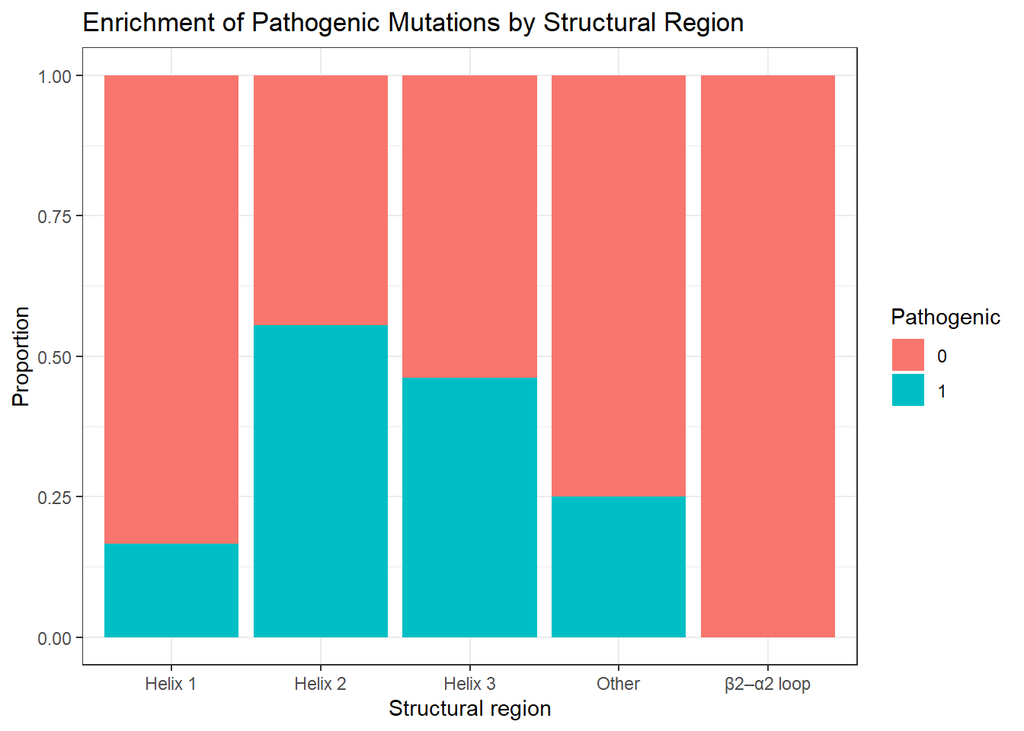

```r
# -------------------------------
# Pathogenic Mutations by region
# -------------------------------

ggplot(mapped_all_mutations, aes(x = region, fill = factor(pathogenic))) +
  geom_bar(position = "fill") +
  theme_bw() +
  labs(
    x = "Structural region",
    y = "Proportion",
    fill = "Pathogenic",
    title = "Enrichment of Pathogenic Mutations by Structural Region"
  )
```

```r
# ------------------------------
# GLM section
# ------------------------------

df_model <- mapped_all_mutations %>%
  mutate(
    region = factor(region),
    region = relevel(region, ref = "Other")
  )

# Model 1 (Full model)

model_1 <- glm(
  pathogenic ~ degree + betweenness + region,
  data = df_model,
  family = binomial
)

# Model 2 (no region)

model_2 <- glm(
  pathogenic ~ degree + betweenness,
  data = df_model,
  family = binomial
)

# Model 3 (degree only)

model_3 <- glm(
  pathogenic ~ degree,
  data = df_model,
  family = binomial
)

# Model 4 (region only)

model_4 <- glm(
  pathogenic ~ region,
  data = df_model,
  family = binomial
)

# Model 5 (betweenness only)

model_5 <- glm(
  pathogenic ~ betweenness,
  data = df_model,
  family = binomial
)

AIC(
  model_1,
  model_2,
  model_3,
  model_4,
  model_5
)
```

```
##         df      AIC
## model_1  7 65.42655
## model_2  3 61.07542
## model_3  2 60.90389
## model_4  5 63.71160
## model_5  2 65.55057
```

```r
#Wilcoxon test (do pathogenic residues have a different degree than non-pathogenic residues)

wilcox.test(degree ~ pathogenic, data = df_model)
```

```
##
##  Wilcoxon rank sum test with continuity correction
##
## data:  degree by pathogenic
## W = 161, p-value = 0.01955
## alternative hypothesis: true location shift is not equal to 0
```

```r
# pathogenic and non pathogenic residues have statistically different degrees. makes sense

# Residue contact degree is the strongest predictor of
# pathogenic mutation occurrence among the tested structural features.
```

# Results

Figure 1: Distribution of Variant Types

Clinvar data was segmented into variant type and the associated pathogenicty.

Figure 2: Pathogenic PRNP mutations by residue

Each bar represents a count of a pathogenic mutation and the position in the PRNP protein.

Figure 3: Distance Map

Figure 4: Contact Network

Figure 5: Permutation test

Each count on the histogram represents the distribution of mean distances between random residues and functional residues over 10,000 randomized trials. The line in red is the observed value of mean distance for high-centrality residues.

Figure 6: amino acid frequency comparison

Figure 7: Enrichment of pathogenic mutations by structural region

Figure 9: AIC and Wilcoxon test results

# Discussion

PRNP mutation variants from Clinvar showcase a predominance in the Single Nucleotide Variant section (figure 1), with the majority of pathogenic mutations being from that category. There were a several pathogenic mutations in the haplotype, inversion, and microsatellite category as well. Based on residue position, the pathogenic variants accumulated most highly around residues 100-150 and 175-230, with a few pathogenic mutations occurring in the beginning portion of the protein (figure 2).

High-centrality residues were shown to be unusually close to functional sites<sup>12</sup>. The test providing a p value less than .05 which indicates residues are closer than expected by chance and suggests real biological clustering<sup>11,15</sup>.

The AIC results indicate that degree alone predicts pathogenicity better than the other predictors in combination (or on their own). Residues with more connections in a local region are likely to be associated with pathogenic mutations. Intuitively, this makes sense as a residue that is largely in isolation will likely have less of an overall affect on the entire way in which a protein may fold.^7

Lastly the Wilcoxon rank sum test indicates pathogenic and non pathogenic residues have statistically different degrees.

# Conclusion

This study demonstrates that structural features of PRNP are strongly associated with the occurrence of pathogenic mutations. Residue contact degree emerged as the strongest predictor of pathogenicity, indicating that local structural connectivity plays a key role in protein stability and disease.

High-centrality residues were also found to cluster significantly near functional regions, supporting a link between network topology and biological function. Pathogenic mutations were enriched in key structural regions such as Helix 2 and Helix 3, consistent with their known roles in prion misfolding.

This project was overall successful in identifying pathogenicity from structure alone, and with further research on the most problematic mutations, ideally lead to therapeutic solutions to prion disease such as CJD. Perhaps fortunately the occurrence of CJD is a rare thing, but it also makes it a challenge to obtain experimental data on for further analysis. Ideally clinicians and scientists will be able to collaborate further to devise proper solutions to handling prion disease and developing a targeted therapy to address the many types of mutations that lead to disease.